# **Introducción a la Modelación de Datos Espaciales usando R**

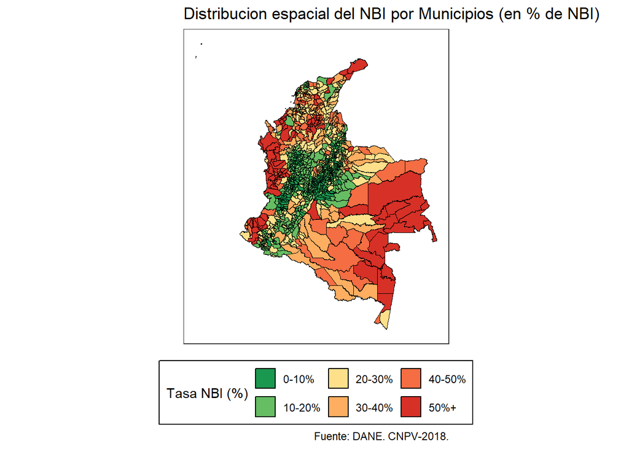

```r
# Figura 4:
mun_merged$tasa_nbi_cat <- cut(mun_merged$tasa_nbi,
                                breaks = c(0, 10, 20, 30, 40, 50, Inf),
                                labels = c("0-10%", "10-20%",
                                           "20-30%", "30-40%",
                                           "40-50%", "50%+"),
                                include.lowest = TRUE)

colors_intervals <- c("0-10%" = "#1a9850",  # Verde
                      "10-20%" = "#66bd63", # Verde claro
                      "20-30%" = "#fee08b", # Amarillo-naranja
                      "30-40%" = "#fdae61", # Naranja
                      "40-50%" = "#f46d43", # Rojo claro
                      "50%+" = "#d73027")   # Rojo fuerte

map_nbi <- ggplot(data = mun_merged) +
  geom_sf(aes(fill = tasa_nbi_cat), color = "black", size = 0.2) +
  scale_fill_manual(values = colors_intervals, name = "Tasa NBI (%)") +
  theme_bw() +
  labs(title = "Distribucion espacial del NBI por Municipios (en % de NBI)",
       caption = "Fuente: DANE. CNPV-2018.") +
  theme(axis.text = element_blank(),
        axis.ticks = element_blank(),
        panel.grid = element_blank(),
        legend.position = "bottom",
        legend.background = element_rect(fill = "white", color = "black"))
map_nbi
```

```r
# Revisión de las conexiones o links del shapefile
nb_mun <- poly2nb(mun_merged)
nb_mun
```

```
## Neighbour list object:
## Number of regions: 1122
## Number of nonzero links: 6570
## Percentage nonzero weights: 0.5218908
## Average number of links: 5.855615
## 2 regions with no links:
## 629, 630
## 3 disjoint connected subgraphs
```

```r
# Eliminar regiones sin enlaces
mun_merged <- mun_merged[-c(629, 630),]

# Revisión de las conexiones o links del shapefile
nb_mun <- poly2nb(mun_merged)
nb_mun
```

```
## Neighbour list object:
## Number of regions: 1120
## Number of nonzero links: 6570
## Percentage nonzero weights: 0.5237564
## Average number of links: 5.866071
```

```r
# Se crea la matriz W
nb2_mun<- nb2listw(nb_mun)
summary(nb2_mun)
```

```
## Characteristics of weights list object:
## Neighbour list object:
## Number of regions: 1120
## Number of nonzero links: 6570
## Percentage nonzero weights: 0.5237564
## Average number of links: 5.866071
## Link number distribution:
##
##   1   2   3   4   5   6   7   8   9  10  11  12  13  14  16  20
##   4  19  55 197 237 249 166  95  52  23  16   2   2   1   1   1
## 4 least connected regions:
## 182 225 408 892 with 1 link
## 1 most connected region:
## 909 with 20 links
##
## Weights style: W
## Weights constants summary:
##      n      nn   S0       S1       S2
## W 1120 1254400 1120 405.6334 4650.468
```

```r
# Examinar la variable dependiente
summary(mun_merged$tasa_nbi)
```

```
##    Min. 1st Qu.  Median    Mean 3rd Qu.    Max.
##    1.59   10.71   16.50   22.71   28.43   95.96
```

```r
# Véase la información de los pesos de la matriz
names(attributes(nb2_mun))  # Nombres de los atributos
```

```
## [1] "names"       "class"       "region.id"   "call"        "zero.policy"
```

```r
card(nb2_mun$neighbours)    # Número de vecinos para cada observación
```

```
##    [1]  8  4  7  5  7  5  5  4  6  7  6 11 16  4  6  4  6  4  6  5  9  7  6  6
##   [25]  8  5  4  3  5  6  6  6  9  7  7  5 10  7  7  4  8  9  4  5  6  9  7  7
##   [49]  3  5  4  5  5 10  4  6  4  4  8  4  8  4  8  6  5  7  6  7  5  5  7  5
##   [73]  4  3  4  4  6  7  4  4  6  5  3  8  6  5  8  4  6  6  9  4  6  6  6  6
##   [97]  6  7  4  7  8  5 10  6  5  2  6  4  6  5  6  8  5  5  6  7  3  5  4  6
##  [121]  5  6  7  8  8  5  4 10  5  4  4  5  4  5  9  4  3  5  7  7  4  6  5  8
##  [145]  6  7  5  5  7  6  6  8  6  8  7  4  4  7  6 10  4  5  6  4  7  5  5  7
##  [169]  9  3  7  4  4  3  6  2  6  4  4  2  4  1  2  5  7  6  2  6  9  8  5  5
##  [193]  4  6  4  5  5  5  5  6  6  6  9  8  5  6  6  7  2  3  6  5  3  6  4  6
##  [217]  2  4  4  5  5  8  2  5  1 10  6  6  5  7  9  7  7  6  4  5  6  7  6  7
##  [241]  7  5  8  5  7  9  6  5  3  6  8  6  8  4  5  8  5  3  8  5  4  6  4  7
##  [265]  6  7  6  9 13  5  6  6  3  5  4  5  6  7  7  5  7  9 11  5  5  6  6  4
##  [289]  5  4  8  5  7  4  7  6  9  8  5  7  7  8  5  5  6  7  6  7 11  8  3  6
##  [313]  4  4  5  4 10  5  5  5  5  7  5 14  6  5  8 11  7  4  8  6  4  6  7  7
##  [337]  6  6  6  6  2  4  7  4  8  4  7  5  6  4  8  4  7  7  4  4  7  7  2  4
```

[output cut: 32 more lines]

```r
range(card(nb2_mun$neighbours))  # Rango (número de vecinos)
```

```
## [1]  1 20
```

```r
1/rev(range(card(nb2_mun$neighbours))) # Rango (pesos)
```

```
## [1] 0.05 1.00
```

```r
summary(nb2_mun, zero.policy=T)   # Resumen
```

```
## Characteristics of weights list object:
## Neighbour list object:
## Number of regions: 1120
## Number of nonzero links: 6570
## Percentage nonzero weights: 0.5237564
## Average number of links: 5.866071
## Link number distribution:
##
##   1   2   3   4   5   6   7   8   9  10  11  12  13  14  16  20
##   4  19  55 197 237 249 166  95  52  23  16   2   2   1   1   1
## 4 least connected regions:
## 182 225 408 892 with 1 link
## 1 most connected region:
## 909 with 20 links
##
## Weights style: W
## Weights constants summary:
##      n      nn   S0       S1       S2
## W 1120 1254400 1120 405.6334 4650.468
```

```r
# - Rechazo o no?
moran.test(mun_merged$tasa_nbi,
           nb2_mun, alternative="two.sided", zero.policy=T)
```

```
##
##  Moran I test under randomisation
##
## data:  mun_merged$tasa_nbi
## weights: nb2_mun
##
## Moran I statistic standard deviate = 40.211, p-value < 2.2e-16
## alternative hypothesis: two.sided
## sample estimates:
## Moran I statistic       Expectation          Variance
##      0.7193363524     -0.0008936550      0.0003208136
```

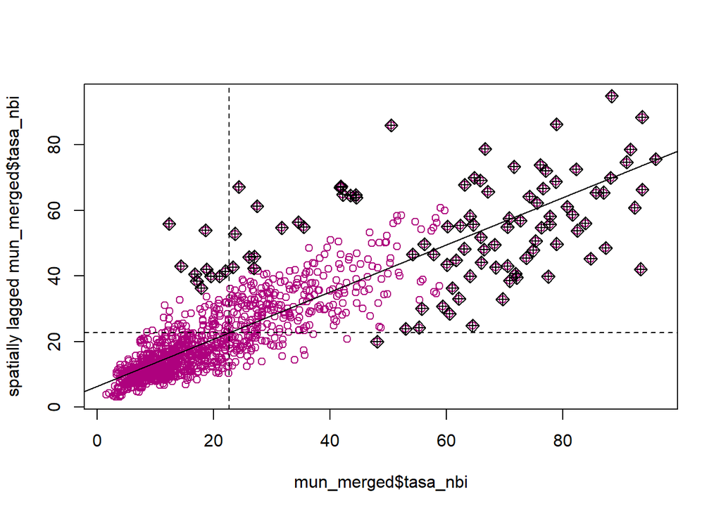

```r
# Moran plot
x <- mun_merged$tasa_nbi
y <- lag.listw(nb2_mun, x, zero.policy = TRUE)
labels <- as.character(mun_merged$nom_mun)

media_x <- mean(x, na.rm = TRUE)
media_y <- mean(y, na.rm = TRUE)

q1 <- which(x < media_x & y < media_y)  # bajo-bajo
q2 <- which(x < media_x & y >= media_y) # bajo-alto
q3 <- which(x >= media_x & y < media_y) # alto-bajo
q4 <- which(x >= media_x & y >= media_y) # alto-alto

set.seed(123)
muns_sel <- c(
  sample(labels[q1], 3),
  sample(labels[q2], 3),
  sample(labels[q3], 3),
  sample(labels[q4], 3)
)

etiquetas <- ifelse(labels %in% muns_sel, labels, "")

moran.plot(x, nb2_mun,
           zero.policy = TRUE,
           labels = etiquetas,
           xlab = "mun_merged$tasa_nbi",
           ylab = "spatially lagged mun_merged$tasa_nbi",
           type = "p", col = "#AE017E", cex = 1, pch = 1)
```

```r
# Para el análisis, se eliminan los valores faltantes
mun_merged2 = mun_merged %>% filter(!is.na(corr_tot) &
                                    !is.na(n) & !is.na(area_km) &
                                     !is.na(ocup_rate))

# Eliminar regiones sin enlaces
mun_merged2 <- mun_merged2[-c(202, 205),]

# Logaritmo natural de la tasa
mun_merged2$log_nbi <- log(mun_merged2$tasa_nbi)

# Se propone una regresión lineal múltiple con las siguientes variables
reg_mco <- lm(log_nbi ~  n + corr_tot + log(area_km) + ocup_rate, data=mun_merged2)
summary(reg_mco)
```

```
##
## Call:
## lm(formula = log_nbi ~ n + corr_tot + log(area_km) + ocup_rate,
##     data = mun_merged2)
##
## Residuals:
##     Min      1Q  Median      3Q     Max
## -1.3135 -0.2943 -0.0243  0.2599  3.3689
##
## Coefficients:
##                Estimate Std. Error t value Pr(>|t|)
## (Intercept)   3.330e+00  1.048e-01  31.781  < 2e-16 ***
## n            -2.520e-07  5.628e-08  -4.477 8.38e-06 ***
## corr_tot     -2.322e+00  1.377e-01 -16.863  < 2e-16 ***
## log(area_km)  2.077e-01  1.176e-02  17.665  < 2e-16 ***
## ocup_rate    -3.297e-02  1.847e-03 -17.851  < 2e-16 ***
## ---
## Signif. codes:  0 '***' 0.001 '**' 0.01 '*' 0.05 '.' 0.1 ' ' 1
##
## Residual standard error: 0.4481 on 1092 degrees of freedom
## Multiple R-squared:  0.5949, Adjusted R-squared:  0.5934
## F-statistic: 400.9 on 4 and 1092 DF,  p-value: < 2.2e-16
```

```r
reg_mco_res <- reg_mco$residuals

#---------------------------------#
# Diagnóstico de los residuales   #
#---------------------------------#

# A continuación examinamos los residuos
me1 <- mean(residuals(reg_mco))
me1
```

```
## [1] -6.675025e-17
```

```r
sd1 <- sd(residuals(reg_mco))
sd1
```

```
## [1] 0.4472586
```

```r
summary(residuals(reg_mco))  # Simetría razonable
```

```
##     Min.  1st Qu.   Median     Mean  3rd Qu.     Max.
## -1.31347 -0.29431 -0.02426  0.00000  0.25986  3.36890
```

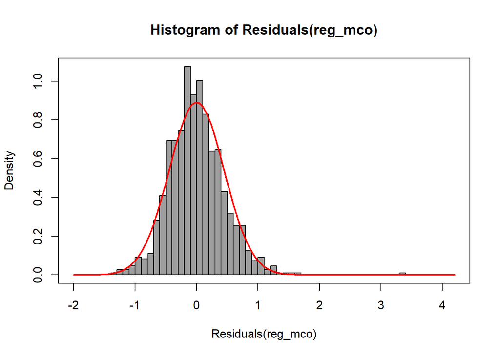

```r
hist(residuals(reg_mco),  breaks=seq(-2, 4.2, 0.1), col=8, probability=T,
     ylab='Density', main='Histogram of Residuals(reg_mco)',
     xlab='Residuals(reg_mco)')
box()
curve(dnorm(x, mean=me1, sd=sd1), from=-2, to=4.2, add=T,
      col='red', lwd=2)
```

```r
# Hay señales de ouliers. Veamos el QQ-plot
library(car)
car::qqPlot(residuals(reg_mco), distribution="norm",
       xlab='', main='Quantile Comparison Plot reg_mco residuals',
       envelope=.95, las=0, pch=NA, lwd=2, col="red",
       line="quartiles")
```

```
## 145 995
## 145 993
```

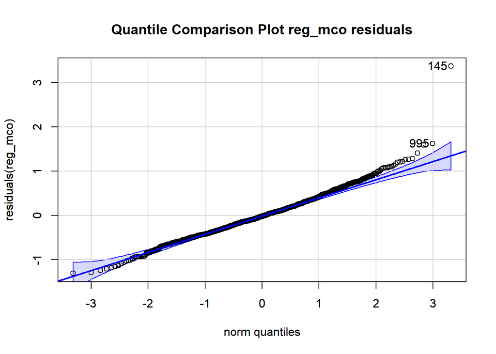

```
## 145 995
## 145 993
```

```r
par(new=TRUE)
car::qqPlot(residuals(reg_mco), distribution="norm", envelope=FALSE,
       pch=1, cex=1, col="black")
```

```r
par(new=FALSE)

# Nuestra intuición se verifica con numerosas pruebas de normalidad univariada
library(nortest)
library(tseries)

ad.test(residuals(reg_mco))
```

```
##
##  Anderson-Darling normality test
##
## data:  residuals(reg_mco)
## A = 2.4306, p-value = 3.794e-06
```

```r
lillie.test(residuals(reg_mco))
```

```
##
##  Lilliefors (Kolmogorov-Smirnov) normality test
##
## data:  residuals(reg_mco)
## D = 0.039553, p-value = 0.0003655
```

```r
pearson.test(residuals(reg_mco))
```

```
##
##  Pearson chi-square normality test
##
## data:  residuals(reg_mco)
## P = 45.426, p-value = 0.03522
```

```r
cvm.test(residuals(reg_mco))
```

```
##
##  Cramer-von Mises normality test
##
## data:  residuals(reg_mco)
## W = 0.40575, p-value = 2.313e-05
```

```r
sf.test(residuals(reg_mco))
```

```
##
##  Shapiro-Francia normality test
##
## data:  residuals(reg_mco)
## W = 0.97633, p-value = 2.62e-11
```

```r
shapiro.test(residuals(reg_mco))
```

```
##
##  Shapiro-Wilk normality test
##
## data:  residuals(reg_mco)
## W = 0.97789, p-value = 6.906e-12
```

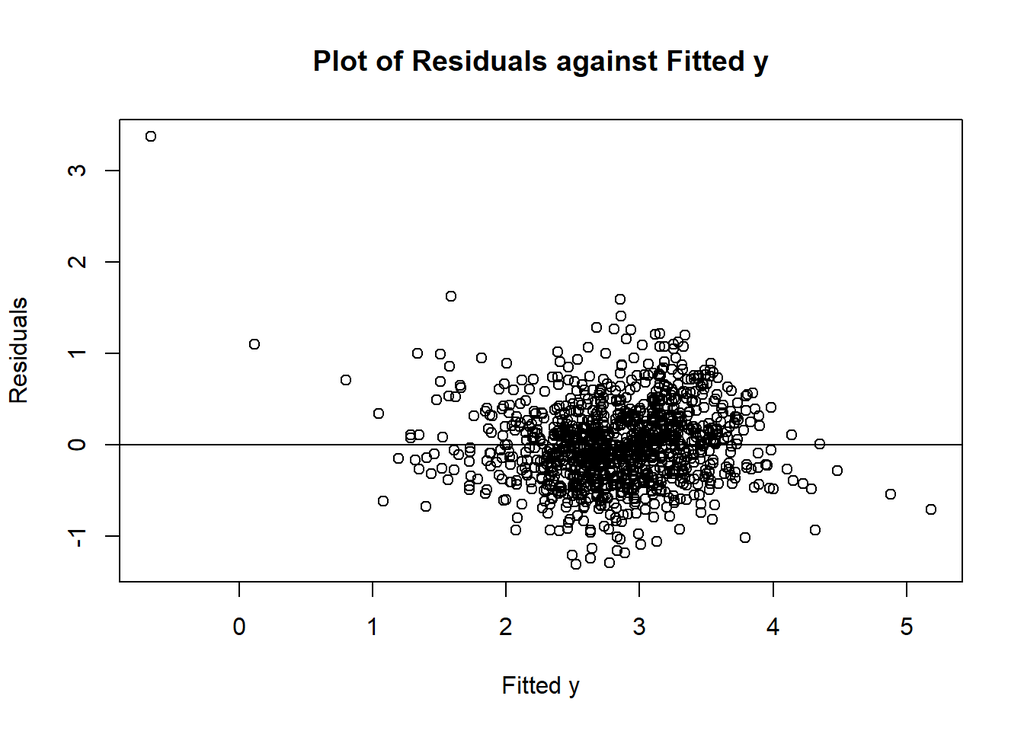

```r
# No hay normalidad en los residuos

# A partir del siguiente gráfico, estudiamos el supuesto de homocedasticidad
plot(fitted(reg_mco), residuals(reg_mco), xlab="Fitted y", ylab= "Residuals",
     main="Plot of Residuals against Fitted y")
abline(h=0)
```

```r
# Usemos una prueba formal:
library(lmtest)
bptest(reg_mco) # Rechaza Ho (Heterocedasticidad)
```

```
##
##  studentized Breusch-Pagan test
##
## data:  reg_mco
## BP = 135.43, df = 4, p-value < 2.2e-16
```

```r
#----------------------------------------------#
# Se verifica la independencia de los residuos #
#----------------------------------------------#

# Se define nuevamente la matriz de pesos
nb_mun <- poly2nb(mun_merged2)
nb_mun
```

```
## Neighbour list object:
## Number of regions: 1097
## Number of nonzero links: 6454
## Percentage nonzero weights: 0.5363098
## Average number of links: 5.883318
```

```r
# Se crea la matriz W
nb2_mun<- nb2listw(nb_mun)
summary(nb2_mun)
```

```
## Characteristics of weights list object:
## Neighbour list object:
## Number of regions: 1097
## Number of nonzero links: 6454
## Percentage nonzero weights: 0.5363098
## Average number of links: 5.883318
## Link number distribution:
##
##   1   2   3   4   5   6   7   8   9  10  11  12  13  14  20
##   3  16  55 192 230 244 165  96  51  23  16   2   2   1   1
## 3 least connected regions:
## 203 388 869 with 1 link
## 1 most connected region:
## 886 with 20 links
##
## Weights style: W
## Weights constants summary:
##      n      nn   S0       S1       S2
## W 1097 1203409 1097 394.4089 4552.689
```

```r
# Véase la información de los pesos de la matriz
names(attributes(nb2_mun))  # Nombres de los atributos
```

```
## [1] "names"       "class"       "region.id"   "call"        "zero.policy"
```

```r
card(nb2_mun$neighbours)    # Número de vecinos para cada observación
```

```
##    [1]  8  4  7  5  7  5  5  4  6  7  6 11 10  4  6  4  6  4  6  5  9  7  6  6
##   [25]  8  5  4  3  5  6  6  6  9  7  7  5 10  7  7  4  8  9  4  5  6  9  7  7
##   [49]  3  5  4  5  5 10  4  6  4  4  8  4  8  4  8  6  5  7  6  7  5  5  7  5
##   [73]  4  3  4  4  6  7  4  4  6  5  3  8  6  5  8  4  6  6  9  4  6  6  6  6
##   [97]  6  7  4  7  8  5 10  6  5  2  6  4  6  5  6  8  3  5  6  7  3  5  4  6
##  [121]  5  6  7  8  8  5  4 10  5  4  4  5  4  5  9  4  3  5  7  7  4  6  5  8
##  [145]  6  7  5  5  7  6  6  8  6  8  7  4  4  7  6 10  4  5  6  4  7  5  5  7
##  [169]  9  3  7  4  4  3  6  2  2  2  6  2  6  8  8  5  5  4  6  4  5  5  5  5
##  [193]  6  6  6  9  8  5  6  6  7  1  3  8  6  4  4  7  9  7  7  6  4  5  6  7
##  [217]  6  7  7  5  8  5  7  9  6  5  3  6  8  6  8  4  5  8  5  3  8  5  4  6
##  [241]  4  7  6  7  6  9 13  5  6  6  3  5  4  5  6  7  7  5  7  9 11  5  5  6
##  [265]  6  4  5  4  8  5  7  4  7  6  9  8  5  7  7  8  5  5  6  7  6  7 11  8
##  [289]  3  6  4  4  5  4 10  5  5  5  5  7  5 14  6  5  8 11  7  4  8  6  4  6
##  [313]  7  7  6  6  6  6  2  4  7  4  8  4  7  5  6  4  8  4  7  7  4  4  7  7
##  [337]  2  4  6  4  7  7  7  6  8  6  9  5  6  9  6  6  6  4  5  3  4  6  4  5
```

[output cut: 31 more lines]

```r
range(card(nb2_mun$neighbours))  # Rango (número de vecinos)
```

```
## [1]  1 20
```

```r
1/rev(range(card(nb2_mun$neighbours))) # Rango (pesos)
```

```
## [1] 0.05 1.00
```

```r
summary(nb2_mun, zero.policy=T)   # Resumen
```

```
## Characteristics of weights list object:
## Neighbour list object:
## Number of regions: 1097
## Number of nonzero links: 6454
## Percentage nonzero weights: 0.5363098
## Average number of links: 5.883318
## Link number distribution:
##
##   1   2   3   4   5   6   7   8   9  10  11  12  13  14  20
##   3  16  55 192 230 244 165  96  51  23  16   2   2   1   1
## 3 least connected regions:
## 203 388 869 with 1 link
## 1 most connected region:
## 886 with 20 links
##
## Weights style: W
## Weights constants summary:
##      n      nn   S0       S1       S2
## W 1097 1203409 1097 394.4089 4552.689
```

```r
moran.test(reg_mco$residuals,
           nb2_mun, alternative="two.sided", zero.policy=T)
```

```
##
##  Moran I test under randomisation
##
## data:  reg_mco$residuals
## weights: nb2_mun
##
## Moran I statistic standard deviate = 20.415, p-value < 2.2e-16
## alternative hypothesis: two.sided
## sample estimates:
## Moran I statistic       Expectation          Variance
##      0.3671633419     -0.0009124088      0.0003250605
```

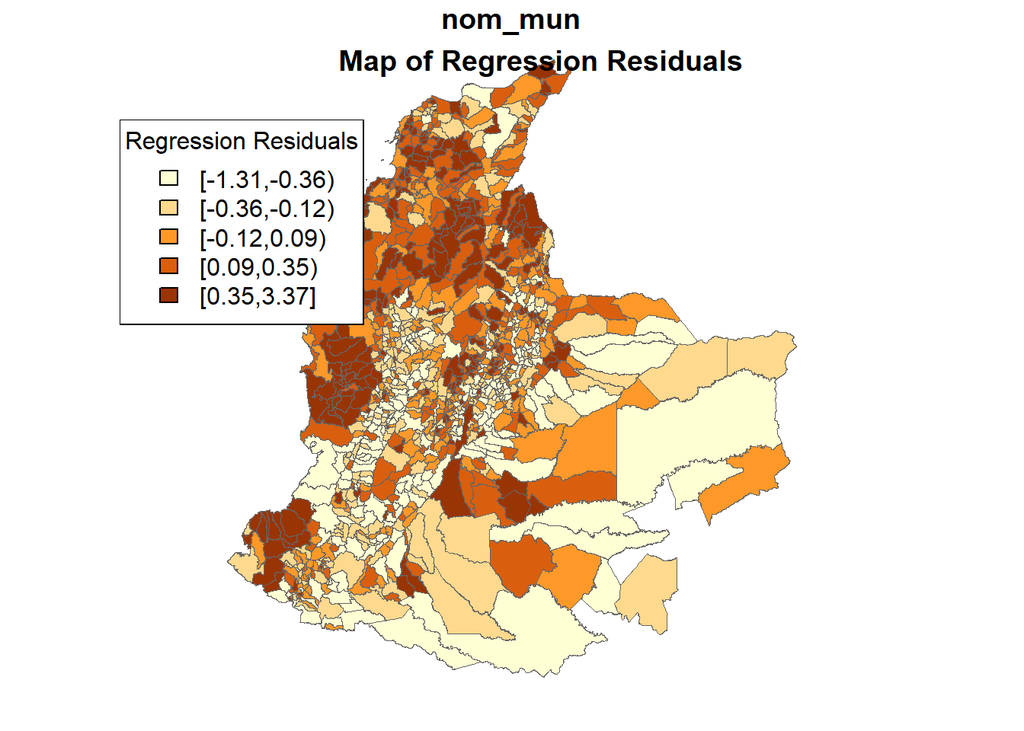

```r
# Seleccionar la paleta
colors <- brewer.pal(5, "YlOrBr")
color.cat.reg<-classIntervals(reg_mco$residuals, n=5, style="quantile", dataPrecision=2)
colcode <- findColours(color.cat.reg, colors)

## Figura
par(mfrow = c(1, 1))
plot(mun_merged2["nom_mun"],
     col = colcode,
     border = "grey40",
     lwd = 0.3)
title("Map of Regression Residuals")
legend("topleft",
       legend = names(attr(colcode, "table")),
       fill = attr(colcode, "palette"),
       title = "Regression Residuals")
```

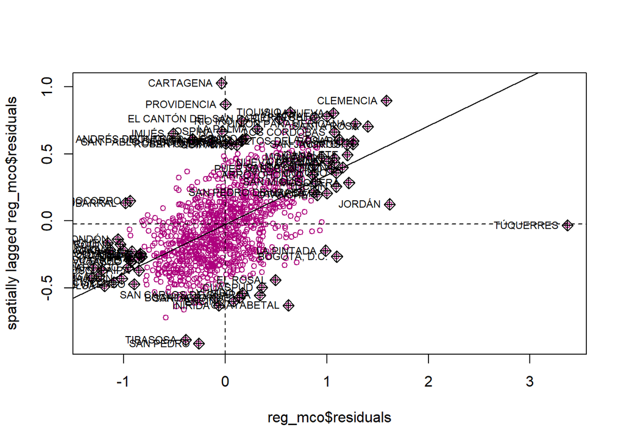

```r
moran.plot(reg_mco$residuals, nb2_mun, zero.policy=T, labels=as.character(mun_merged2$nom_mun),
           xlab=NULL, ylab=NULL, type="p", col="#AE017E",
           cex=0.8, pch=1)
```

## 1.2 Modelo espacial autorregresivo (SAR) - Spillovers o efectos derramamiento

- Incorpora dependencia espacial agregando un “rezago espacial” a la variable dependiente en el lado derecho de la ecuación de regresión.
- Trata la correlación espacial como un proceso o efecto de interés.
  - Los valores de $y$ en un área están directamente influenciados por los valores de $y$ encontrados en áreas vecinas.
  - Depende de cómo definimos el vecindario.

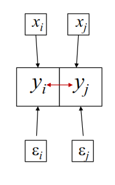

$$\boldsymbol{y}= \rho \boldsymbol{Wy} + \boldsymbol{X} \beta +
\boldsymbol{\varepsilon} \\
[\boldsymbol{I} - \boldsymbol{W}\rho]\boldsymbol{y} = \boldsymbol{X}
\beta + \boldsymbol{\varepsilon} \\
\boldsymbol{y} = [\boldsymbol{I} -
\boldsymbol{W}\rho]^{-1}\boldsymbol{X} \beta + [\boldsymbol{I} -
\boldsymbol{W}\rho]^{-1}\boldsymbol{\varepsilon}$$

- Efectos marginales son:

$$\frac{\partial \boldsymbol{y}}{\partial \boldsymbol{X}} =
[\boldsymbol{I} - \boldsymbol{W}\rho]^{-1}\boldsymbol{I}\beta$$

- De esta expresión se descompone el efecto en directo, total e indirecto.

$$\overline{M_{tot}}=n^{-1}i^{'}V(\boldsymbol{W})\beta i \\
\overline{M_{dir}}=n^{-1}tr(V(\boldsymbol{W}))\beta \\
\overline{M_{indir}}=\overline{M_{tot}}-\overline{M_{dir}}$$

- Se estima por el método de Máxima Verosimilitud.

```r
model.lag.eig <- spatialreg::lagsarlm(log_nbi ~  n + corr_tot + log(area_km) + ocup_rate,
                       data=mun_merged2, nb2_mun, method="eigen", quiet=FALSE)
```

```
##
## Spatial lag model
## Jacobian calculated using neighbourhood matrix eigenvalues
## Computing eigenvalues ...
##
## rho:  -0.5106785     function value:  -1034.237
## rho:  0.06634936     function value:  -628.5583
## rho:  0.4229722  function value:  -429.703
## rho:  0.6433772  function value:  -382.9689
## rho:  0.7102037  function value:  -387.6593
## rho:  0.6410738  function value:  -382.9844
## rho:  0.6452626  function value:  -382.9646
## rho:  0.6453691  function value:  -382.9646
## rho:  0.6453666  function value:  -382.9646
## rho:  0.6453666  function value:  -382.9646
## rho:  0.6453666  function value:  -382.9646
## rho:  0.6453666  function value:  -382.9646
## rho:  0.6453666  function value:  -382.9646
```

```r
summary(model.lag.eig)
```

```
##
## Call:spatialreg::lagsarlm(formula = log_nbi ~ n + corr_tot + log(area_km) +
##     ocup_rate, data = mun_merged2, listw = nb2_mun, method = "eigen",
##     quiet = FALSE)
##
## Residuals:
##        Min         1Q     Median         3Q        Max
## -1.0256524 -0.2061123  0.0067949  0.2030983  1.4588626
##
## Type: lag
## Coefficients: (asymptotic standard errors)
##                 Estimate  Std. Error  z value  Pr(>|z|)
## (Intercept)   1.4283e+00  1.0170e-01  14.0441 < 2.2e-16
## n            -2.1658e-07  4.1234e-08  -5.2525 1.501e-07
## corr_tot     -1.1178e+00  1.0754e-01 -10.3942 < 2.2e-16
## log(area_km)  8.3097e-02  9.5011e-03   8.7460 < 2.2e-16
## ocup_rate    -1.8057e-02  1.4685e-03 -12.2963 < 2.2e-16
##
## Rho: 0.64537, LR test value: 580.89, p-value: < 2.22e-16
## Asymptotic standard error: 0.021466
##     z-value: 30.065, p-value: < 2.22e-16
## Wald statistic: 903.92, p-value: < 2.22e-16
##
## Log likelihood: -382.9646 for lag model
## ML residual variance (sigma squared): 0.10752, (sigma: 0.32791)
## Number of observations: 1097
## Number of parameters estimated: 7
## AIC: 779.93, (AIC for lm: 1358.8)
## LM test for residual autocorrelation
## test value: 0.071348, p-value: 0.78938
```

```r
model.lag.eig.imp <- impacts(model.lag.eig, listw = nb2_mun, R = 999)
summary(model.lag.eig.imp, zstats = TRUE, short = TRUE)
```

```
## Impact measures (lag, exact):
##                     Direct      Indirect         Total
## n            -2.403708e-07 -3.703475e-07 -6.107184e-07
## corr_tot     -1.240536e+00 -1.911337e+00 -3.151873e+00
## log(area_km)  9.222493e-02  1.420941e-01  2.343190e-01
## ocup_rate    -2.004095e-02 -3.087777e-02 -5.091871e-02
## ========================================================
## Simulation results ( variance matrix):
## ========================================================
## Simulated standard errors
##                    Direct     Indirect        Total
## n            4.534062e-08 7.738921e-08 1.203164e-07
## corr_tot     1.166280e-01 2.067486e-01 2.975172e-01
## log(area_km) 1.005544e-02 1.586818e-02 2.411413e-02
## ocup_rate    1.573486e-03 2.992779e-03 4.089248e-03
##
## Simulated z-values:
##                  Direct   Indirect      Total
## n             -5.262020  -4.770548  -5.051450
## corr_tot     -10.620690  -9.248918 -10.590554
## log(area_km)   9.143943   8.934927   9.692546
## ocup_rate    -12.785254 -10.378940 -12.515576
##
## Simulated p-values:
##              Direct     Indirect   Total
## n            1.4248e-07 1.8373e-06 4.3847e-07
## corr_tot     < 2.22e-16 < 2.22e-16 < 2.22e-16
## log(area_km) < 2.22e-16 < 2.22e-16 < 2.22e-16
## ocup_rate    < 2.22e-16 < 2.22e-16 < 2.22e-16
```

## 1.3 Modelo de error espacial (SEM) - Heterogeneidad espacial u omisión de variables

- Examina la autocorrelación espacial entre los residuos de áreas adyacentes.
- Trata la correlación espacial principalmente como un problema.
  - Desestima la idea de que la correlación espacial pueda reflejar algún proceso significativo.
- El error espacial positivo puede reflejar:
  - Un modelo mal especificado (particularmente una variable omitida que está espacialmente desordenada).
  - Unidad espacial de agregación incorrecta.

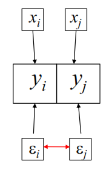

$$\boldsymbol{y}= \boldsymbol{X} \beta + \boldsymbol{u} \\$$

$$\boldsymbol{u} = \lambda \boldsymbol{Wu} + \boldsymbol{\varepsilon} \\
\boldsymbol{u} = [\boldsymbol{I} -
\boldsymbol{W}\lambda]^{-1}\boldsymbol{\varepsilon}$$

- Reemplazo en estructural,

$$\boldsymbol{y}= \boldsymbol{X} \beta + [\boldsymbol{I} -
\boldsymbol{W}\lambda]^{-1}\boldsymbol{\varepsilon} \\$$

- Efectos marginales son:

$$\frac{\partial \boldsymbol{y}}{\partial \boldsymbol{X}} =
\boldsymbol{I}\beta$$

- Se estima por el método de Máxima Verosimilitud.

```r
model.err.eig <- spatialreg::errorsarlm(log_nbi ~  n + corr_tot + log(area_km) + ocup_rate,
                         data=mun_merged2, nb2_mun, method="eigen", quiet=FALSE)
```

```
##
## Spatial autoregressive error model
##
## Jacobian calculated using neighbourhood matrix eigenvalues
## Computing eigenvalues ...
##
## lambda: -0.5106785  function: -899.8124  Jacobian: -22.53523  SSE: 317.942
## lambda: 0.06634936  function: -647.0561  Jacobian: -0.4133826  SSE: 208.802
## lambda: 0.4229722  function: -518.6232  Jacobian: -18.88901  SSE: 159.7404
## lambda: 0.6433772  function: -455.1304  Jacobian: -49.19791  SSE: 134.6306
## lambda: 0.779595  function: -432.9128  Jacobian: -80.42394  SSE: 122.1316
## lambda: 0.9442065  function: -457.2779  Jacobian: -147.0443  SSE: 113.0761
## lambda: 0.7903406  function: -432.2619  Jacobian: -83.51204  SSE: 121.3018
## lambda: 0.8283862  function: -431.8305  Jacobian: -95.44469  SSE: 118.5981
## lambda: 0.8726256  function: -435.8241  Jacobian: -111.7433  SSE: 115.9671
## lambda: 0.8149801  function: -431.6238  Jacobian: -91.04897  SSE: 119.5073
## lambda: 0.8145832  function: -431.6239  Jacobian: -90.92218  SSE: 119.535
## lambda: 0.8149299  function: -431.6238  Jacobian: -91.03294  SSE: 119.5108
## lambda: 0.8149342  function: -431.6238  Jacobian: -91.03432  SSE: 119.5105
## lambda: 0.8149342  function: -431.6238  Jacobian: -91.03432  SSE: 119.5105
## lambda: 0.8149338  function: -431.6238  Jacobian: -91.03419  SSE: 119.5106
## lambda: 0.8149341  function: -431.6238  Jacobian: -91.03427  SSE: 119.5105
## lambda: 0.8149342  function: -431.6238  Jacobian: -91.0343  SSE: 119.5105
## lambda: 0.8149342  function: -431.6238  Jacobian: -91.03431  SSE: 119.5105
## lambda: 0.8149342  function: -431.6238  Jacobian: -91.03432  SSE: 119.5105
```

```r
summary(model.err.eig)
```

```
##
## Call:spatialreg::errorsarlm(formula = log_nbi ~ n + corr_tot + log(area_km) +
##     ocup_rate, data = mun_merged2, listw = nb2_mun, method = "eigen",
##     quiet = FALSE)
##
## Residuals:
##        Min         1Q     Median         3Q        Max
## -1.0971364 -0.2052636 -0.0023508  0.2165170  1.4411379
##
## Type: error
## Coefficients: (asymptotic standard errors)
##                 Estimate  Std. Error  z value  Pr(>|z|)
## (Intercept)   3.3823e+00  1.0796e-01  31.3280 < 2.2e-16
## n            -1.7569e-07  3.5865e-08  -4.8987 9.645e-07
## corr_tot     -1.0369e+00  1.1893e-01  -8.7185 < 2.2e-16
## log(area_km)  8.7141e-02  1.3725e-02   6.3489 2.168e-10
## ocup_rate    -2.1447e-02  1.6202e-03 -13.2376 < 2.2e-16
##
## Lambda: 0.81493, LR test value: 483.57, p-value: < 2.22e-16
## Asymptotic standard error: 0.020808
##     z-value: 39.164, p-value: < 2.22e-16
## Wald statistic: 1533.8, p-value: < 2.22e-16
##
## Log likelihood: -431.6238 for error model
## ML residual variance (sigma squared): 0.10894, (sigma: 0.33007)
## Number of observations: 1097
## Number of parameters estimated: 7
## AIC: 877.25, (AIC for lm: 1358.8)
```

```r
htmlreg(list(reg_mco, model.lag.eig, model.err.eig),
        file = "OLS_SAR_SEM.html",
        custom.model.names = c("OLS", "SAR", "SEM"),
        single.row = TRUE) # El resultado se muestra en oro archivo
```

# 2 **Test de identificación del tipo de modelación espacial**

## 2.1 Elegir entre modelos: AIC y SC

- AIC = $-2L + 2k$
  - donde L es la log-verosimilitud y k es el número de parámetros del modelo.
- SC = $-2L + kln(N)$ (también conocido como BIC)
  - donde N es el número de observaciones

## 2.2 Comentarios técnicos

Pasos para determinar el grado de autocorrelación espacial de los datos y ejecutar una regresión espacial:

1. Elija un criterio de vecindad ¿Qué zonas están relacionadas?
2. Asigne ponderaciones a las zonas que están vinculadas
3. Crear una matriz de ponderaciones espaciales
4. Ejecutar una prueba estadística para examinar la autocorrelación espacial
5. Ejecutar una regresión MCO
6. Determinar qué tipo de regresión espacial ejecutar
7. Ejecutar una regresión espacial
8. Aplicar la matriz de pesos

```r
# Test de multiplicadores de Lagrange (i.e. GeoDa-style Lagrange multiplier tests)
lm.LMtests(reg_mco, nb2_mun, test=c("LMerr", "LMlag", "RLMerr", "RLMlag"))
```

```
##
##  Rao's score (a.k.a Lagrange multiplier) diagnostics for spatial
##  dependence
##
## data:
## model: lm(formula = log_nbi ~ n + corr_tot + log(area_km) + ocup_rate,
## data = mun_merged2)
## test weights: listw
##
## RSerr = 411.33, df = 1, p-value < 2.2e-16
##
##
##  Rao's score (a.k.a Lagrange multiplier) diagnostics for spatial
##  dependence
##
## data:
## model: lm(formula = log_nbi ~ n + corr_tot + log(area_km) + ocup_rate,
## data = mun_merged2)
## test weights: listw
##
## RSlag = 570.26, df = 1, p-value < 2.2e-16
##
##
##  Rao's score (a.k.a Lagrange multiplier) diagnostics for spatial
##  dependence
##
## data:
## model: lm(formula = log_nbi ~ n + corr_tot + log(area_km) + ocup_rate,
## data = mun_merged2)
## test weights: listw
##
## adjRSerr = 26.942, df = 1, p-value = 2.097e-07
##
##
##  Rao's score (a.k.a Lagrange multiplier) diagnostics for spatial
##  dependence
##
## data:
## model: lm(formula = log_nbi ~ n + corr_tot + log(area_km) + ocup_rate,
## data = mun_merged2)
## test weights: listw
##
## adjRSlag = 185.88, df = 1, p-value < 2.2e-16
```

```r
# Veamos la comparación de la autocorrelación en los residuos
moran.test(reg_mco$residuals, nb2_mun, alternative="two.sided")
```

```
##
##  Moran I test under randomisation
##
## data:  reg_mco$residuals
## weights: nb2_mun
##
## Moran I statistic standard deviate = 20.415, p-value < 2.2e-16
## alternative hypothesis: two.sided
## sample estimates:
## Moran I statistic       Expectation          Variance
##      0.3671633419     -0.0009124088      0.0003250605
```

```r
moran.test(model.lag.eig$residuals, nb2_mun, alternative="two.sided")
```

```
##
##  Moran I test under randomisation
##
## data:  model.lag.eig$residuals
## weights: nb2_mun
##
## Moran I statistic standard deviate = -0.14935, p-value = 0.8813
## alternative hypothesis: two.sided
## sample estimates:
## Moran I statistic       Expectation          Variance
##     -0.0036081200     -0.0009124088      0.0003257897
```

```r
moran.test(model.err.eig$residuals, nb2_mun, alternative="two.sided")
```

```
##
##  Moran I test under randomisation
##
## data:  model.err.eig$residuals
## weights: nb2_mun
##
## Moran I statistic standard deviate = -3.0634, p-value = 0.002188
## alternative hypothesis: two.sided
## sample estimates:
## Moran I statistic       Expectation          Variance
##     -0.0562070651     -0.0009124088      0.0003257971
```

```r
# REVISAR CONCLUSIÓN: Lag, SARAR, & SDM all pretty good.  Error is OK.  The rest: not so much.

# Veamos la comparación según los criterios de información
AIC(reg_mco)       # 1358.818
```

```
## [1] 1358.818
```

```r
AIC(model.lag.eig)    # 779.9292
```

```
## [1] 779.9292
```

```r
AIC(model.err.eig)    # 877.2476
```

```
## [1] 877.2476
```

```r
BIC(reg_mco)       # 1388.82
```

```
## [1] 1388.82
```

```r
BIC(model.lag.eig)    # 814.9316
```

```
## [1] 814.9316
```

```r
BIC(model.err.eig)    # 912.25
```

```
## [1] 912.25
```

# 3 **(OPCIONAL) Otros modelos: SLX y SAC**

## 3.1 Modelo de rezago Espacial de las X’s (SLX)

$$\boldsymbol{y}= \boldsymbol{X} \beta + \boldsymbol{WX} \theta +
\boldsymbol{\varepsilon} \\$$

```r
model.slx.eig <- spatialreg::lmSLX(tasa_nbi ~ n + corr_tot + log(area_km) + ocup_rate,
                         data=mun_merged2, nb2_mun)
summary(model.slx.eig)
```

```
##
## Call:
## lm(formula = formula(paste("y ~ ", paste(colnames(x)[-1], collapse = "+"))),
##     data = as.data.frame(x), weights = weights)
##
## Coefficients:
##                   Estimate    Std. Error  t value     Pr(>|t|)
## (Intercept)        3.093e+01   3.896e+00   7.939e+00   5.050e-15
## n                 -1.709e-06   1.418e-06  -1.205e+00   2.284e-01
## corr_tot          -1.893e+01   4.061e+00  -4.662e+00   3.517e-06
## log.area_km.       2.182e+00   4.800e-01   4.547e+00   6.065e-06
## ocup_rate         -5.408e-01   5.530e-02  -9.780e+00   1.043e-21
## lag.n              4.785e-06   1.929e-06   2.481e+00   1.325e-02
## lag.corr_tot      -4.025e+01   6.617e+00  -6.083e+00   1.630e-09
## lag.log.area_km.   3.479e+00   6.133e-01   5.672e+00   1.805e-08
## lag.ocup_rate     -2.914e-01   8.731e-02  -3.338e+00   8.726e-04
```